# R example 7: propensity score matching and inverse probability weighting

Did job training raise earnings in 1978? We return to the 185 National Supported Work trainees and 429 PSID controls from Example 6.

In Example 6, we compared earnings within propensity score blocks. Here we start with the same eligible sample and use two other approaches. Matching estimates the ATT among trainees who find a match. Inverse probability weighting (IPW) estimates the ATE among all eligible trainees and controls.

## 1. Job training, earnings, and overlap

### Step 1. Estimate the training probabilities

Start with the propensity score model from Example 6. We match on the linearized propensity score and use the fitted probabilities to calculate the weights.

```r
library(MatchIt)
library(ggplot2)
data("lalonde")
ps_formula <- treat ~ age + educ + race + married + nodegree + re74 + re75
fit <- glm(ps_formula, data = lalonde, family = binomial())
lalonde$score <- fitted(fit)
lalonde$logit_score <- predict(fit, type = "link")
lalonde$group <- factor(lalonde$treat, levels = 0:1, labels = c("Control", "Trainee"))
```

```r
lalonde$black <- as.integer(lalonde$race == "black")
vars <- c("re74", "re75", "married", "black")
controls <- lalonde$treat == 0
trainees <- lalonde$treat == 1

baseline_means <- rbind(
  Controls = colMeans(lalonde[controls, vars]),
  Trainees = colMeans(lalonde[trainees, vars])
)
round(baseline_means, 2)
```

```
##             re74    re75 married black
## Controls 5619.24 2466.48    0.51  0.20
## Trainees 2095.57 1532.06    0.19  0.84
```

Trainees earned an average of $2,096 in 1974, compared with $5,619 for controls. The proportions recorded as Black were 84% and 20%. How much of these differences will remain after matching?

### Step 2. Use the eligible sample from Example 6

To compare matching and weighting with stratification in Example 6, we start with the same people. We keep those whose estimated propensity scores are between 0.10 and 0.90 and within the range observed in both groups.

```r
score_ranges <- with(lalonde, rbind(Controls = range(score[treat == 0]),
                                    Trainees = range(score[treat == 1])))
e_L <- max(score_ranges[, 1])
e_U <- min(score_ranges[, 2])
ate_weights <- function(z, score) ifelse(z == 1, 1 / score, 1 / (1 - score))
lalonde$w <- with(lalonde, ate_weights(treat, score))
common_range <- subset(lalonde, score >= e_L & score <= e_U)
fixed_range <- subset(lalonde, score >= 0.10 & score <= 0.90)
job <- subset(fixed_range, score >= e_L & score <= e_U)

counts <- rbind("Full sample" = table(lalonde$group),
                "Common range only" = table(common_range$group),
                "0.10 to 0.90 only" = table(fixed_range$group),
                "Both restrictions" = table(job$group))
max_weight <- c(max(lalonde$w), max(common_range$w), max(fixed_range$w), max(job$w))
cbind(counts, Total = rowSums(counts), Max_ATE_weight = round(max_weight, 1))
```

```
##                   Control Trainee Total Max_ATE_weight
## Full sample           429     185   614           40.1
## Common range only     372     177   549           40.1
## 0.10 to 0.90 only     166     175   341           10.0
## Both restrictions     166     167   333           10.0
```

This leaves 167 trainees and 166 controls. Using the 0.10–0.90 cutoffs alone would retain eight more trainees.

### Step 3. Check where controls are scarce

Are there enough controls near the trainees with high scores? The horizontal axis shows the **estimated linearized propensity score**, $\log\{\hat e_i/(1-\hat e_i)\}$, where $\hat e_i$ is person $i$’s fitted probability of training. The solid line at zero corresponds to $\hat e_i = 0.5$. The dashed lines mark the eligibility limits ($\hat e_i = 0.10$ and $\hat e_i \approx 0.789$).

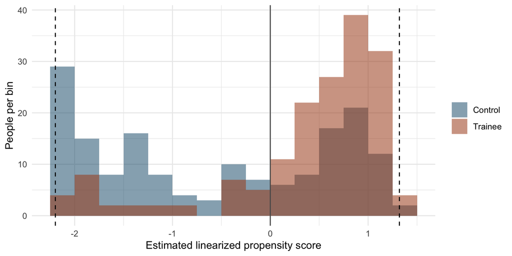

```r
ggplot(job, aes(logit_score, fill = group)) +
  geom_histogram(binwidth = 0.25, boundary = 0, position = "identity", alpha = 0.55) +
  geom_vline(xintercept = qlogis(c(max(0.10, e_L), min(0.90, e_U))), linetype = 2) +
  geom_vline(xintercept = 0, color = "grey35") +
  scale_fill_manual(values = c("#286481", "#AB4D20")) +
  labs(x = "Estimated linearized propensity score", y = "People per bin", fill = NULL) +
  theme_minimal()
```

```r
with(job, table(group, score_above_half = score > 0.5))
```

```
##          score_above_half
## group     FALSE TRUE
##   Control   100   66
##   Trainee    32  135
```

Of the 167 trainees, 135 have a score above 0.5, compared with only 66 controls. At least 69 of those trainees must take a lower-score partner or go unmatched in a one-to-one match without replacement. There are only 166 controls in total, so at least one trainee will be unmatched.

## 2. Match trainees to controls

### Step 1. Compare greedy and optimal pairs and check balance

For each trainee and control, define their distance as the absolute difference between their linearized propensity scores. Greedy matching starts with the highest-score trainee and takes the closest available control. Optimal matching chooses the pairs jointly to minimize their total distance.

```r
greedy <- matchit(ps_formula, data = job, distance = job$logit_score, estimand = "ATT",
                  method = "nearest", m.order = "largest")
optimal <- matchit(ps_formula, data = job, distance = job$logit_score, estimand = "ATT",
                   method = "optimal", tol = 1e-7)
logit <- setNames(job$logit_score, rownames(job))
pair_distance <- function(m) {
  partner <- na.omit(m$match.matrix[, 1])
  abs(logit[names(partner)] - logit[partner])
}
distances <- function(d) {
  c(Mean = mean(d), Median = median(d), Maximum = max(d), Above_one = sum(d > 1))
}
greedy_gap <- pair_distance(greedy)
optimal_gap <- pair_distance(optimal)
round(rbind(Greedy = distances(greedy_gap), Optimal = distances(optimal_gap)), 2)
```

```
##         Mean Median Maximum Above_one
## Greedy  0.98   0.82    2.13        76
## Optimal 0.96   0.63    3.28        65
```

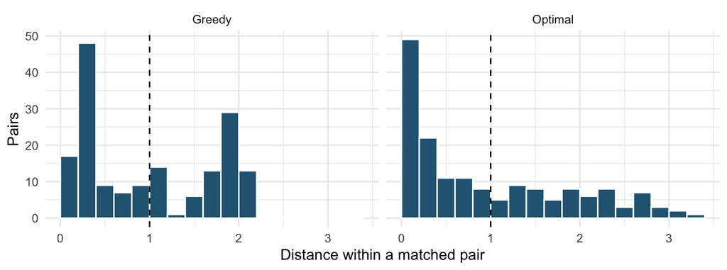

Both algorithms form 166 pairs. Optimal matching reduces the mean distance from 0.98 to 0.96, but its largest distance still exceeds 3. Minimizing the total distance can leave individual trainees with distant partners.

**Are the covariates balanced after matching?** For each baseline covariate, we calculate the **standardized mean difference (SMD)** by dividing the difference in group means (trainees minus controls) by the standard deviation among the 167 eligible trainees. After matching, we use the matching weights for the group means and keep the denominator fixed. The dashed lines mark SMDs of −0.10 and 0.10.

```r
# One column per covariate or race indicator. Row names identify people across designs.
x <- model.matrix(~ 0 + race + age + educ + married + nodegree + re74 + re75, lalonde)
treated_sd <- apply(x[rownames(job)[job$treat == 1], , drop = FALSE], 2, sd)
smd <- function(d, w, reference_sd) {
  baseline <- x[rownames(d), , drop = FALSE]
  treated <- d$treat == 1
  gap <- apply(baseline, 2, function(v) {
    weighted.mean(v[treated], w[treated]) - weighted.mean(v[!treated], w[!treated])
  })
  gap / reference_sd
}
```

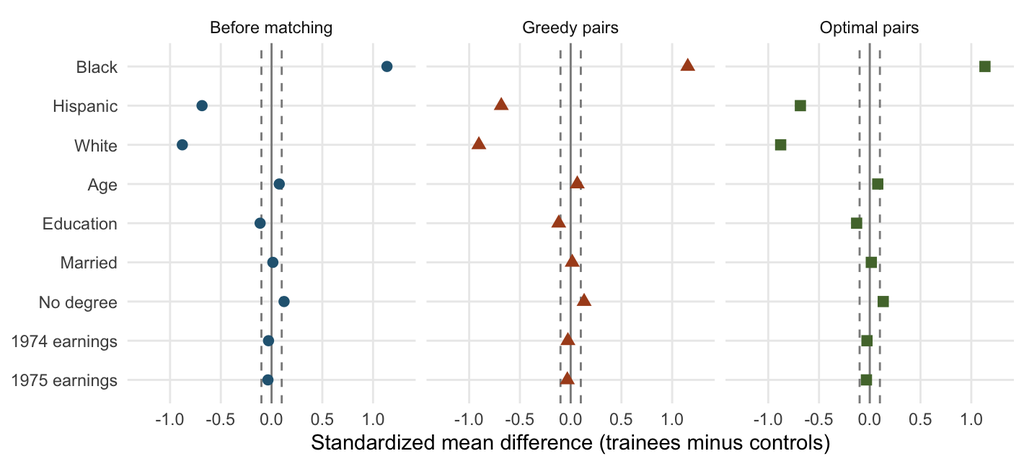

```r
initial_balance <- cbind(
  "Before matching" = smd(job, rep(1, nrow(job)), treated_sd),
  "Greedy pairs" = smd(job, greedy$weights, treated_sd),
  "Optimal pairs" = smd(job, optimal$weights, treated_sd)
)
balance_plot(initial_balance) + facet_wrap(~ design, nrow = 1) +
  theme(legend.position = "none")
```

Race shows the largest imbalance. Among the 166 optimal pairs, 147 trainees (88.6%) and 87 controls (52.4%) are Black. The SMD for this indicator changes only from 1.14 to 1.13. These pairs use every eligible control and all but one trainee, so rearranging the partners can do little to change the group proportions.

### Step 2. Improve the matches

**Try matching exactly on race.** One way to address the imbalance is to require each trainee and control in a pair to have the same race. Of the 148 eligible Black trainees, at most 87 can then find a partner. How many pairs can we form across the three race categories?

```r
exact <- update(optimal, exact = ~ race)
with(job[exact$weights > 0, ], table(group, race))
```

```
##          race
## group     black hispan white
##   Control    87     10     9
##   Trainee    87     10     9
```

**Drop trainees with distant partners and rematch.** Start with the optimal pairs and identify trainees whose distance from their matched control exceeds 1. Drop those trainees and rerun optimal matching with *all* controls available again. Check the distances a second time. This rule screens the first set of pairs and gives no distance guarantee for the new pairs.

```r
initial_gap <- pair_distance(optimal)
drop_ids <- names(initial_gap)[initial_gap > 1]
closer_pool <- job[!rownames(job) %in% drop_ids, ]
rematch <- update(optimal, data = closer_pool, distance = closer_pool$logit_score)
c(Trainees_removed = length(drop_ids), New_gaps_above_one = sum(pair_distance(rematch) > 1))
```

```
##   Trainees_removed New_gaps_above_one
##                 65                  4
```

**Allow controls to contribute to several comparisons.** Match each trainee to their two closest controls with replacement. A control may serve several trainees, so count how many distinct people supply the control outcomes. As a second way to handle the shortage, try optimal full matching. It forms sets of one trainee and one or more controls, or one control and one or more trainees. For the ATT, controls receive more weight in sets with more trainees per control.

```r
reuse <- matchit(ps_formula, data = job, distance = job$logit_score, estimand = "ATT",
                 method = "nearest", replace = TRUE, ratio = 2)
full <- update(optimal, method = "full")
uses <- sort(table(as.vector(reuse$match.matrix)), decreasing = TRUE)
head(uses, 5)
```

```
##
## PSID196 PSID226 PSID291 PSID367 PSID217
##      18      17      11      10       9
```

### Step 3. Check covariate balance and identify the retained trainees

How many trainees does each design retain, and how well does it balance their baseline covariates?

```
##                       Trainees Controls Black_SMD Max_SMD Covariate
## Before matching            167      166      1.14   1.137 raceblack
## Greedy pairs               166      166      1.15   1.154 raceblack
## Optimal pairs              166      166      1.13   1.135 raceblack
## Exact on race              106      106      0.00   0.104  nodegree
## Drop and rematch           102      102      0.03   0.251   married
## With replacement           167      108      0.02   0.177   married
## Optimal full matching      167      166      0.03   0.178   married
```

Full matching keeps all 167 trainees and reduces the SMD for the Black indicator to 0.03. The figure compares the two designs used for the earnings analysis.

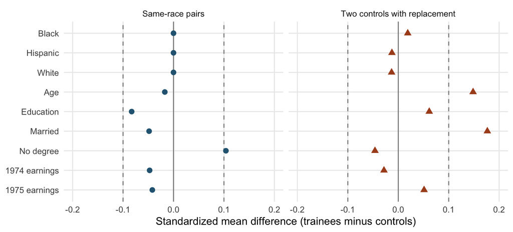

In the same-race pairs, all three race indicators are balanced exactly. Only “No degree” falls just outside the ±0.10 lines (SMD 0.104).

The next table compares pre-training earnings and propensity scores for the 106 matched and 61 unmatched trainees.

```r
trainees <- job[job$treat == 1, ]
matched <- exact$weights[rownames(trainees)] > 0
vars <- c("score", "re74", "re75")
trainee_means <- rbind(
  Unmatched = colMeans(trainees[!matched, vars]),
  Matched   = colMeans(trainees[matched, vars])
)
round(trainee_means, 2)
```

```
##           score    re74    re75
## Unmatched  0.70 1032.44  995.70
## Matched    0.54 2858.12 1801.07
```

The excluded trainees earned an average of $1,032 in 1974 and had a mean score of 0.70. The corresponding figures for matched trainees were $2,858 and 0.54. An effect among the 106 matched trainees may differ from the effect among all 167. Dropping poor pairs also changes the target and leaves residual imbalance in marital status. With replacement, all 167 trainees find two partners using 108 distinct controls. One control is used 18 times. Full matching uses all 166 controls.

## 3. Estimate the ATT among matched trainees

Use the subsection for the matching design you chose in Section 2. In either design, calculate one earnings difference per matched trainee and average those differences. For regression adjustment, use the same pretreatment covariates as in the propensity score model.

```r
control_formula <- update(ps_formula, re78 ~ .)
interval <- function(est, se) {
  c(Estimate = unname(est), SE = unname(se),
    Lower = unname(est - 1.96 * se), Upper = unname(est + 1.96 * se))
}
```

### One-to-one matching within race

**Matched estimate.** For each of the 106 matched trainees, subtract the 1978 earnings of their same-race control. As in Example 4, the paired standard error uses the variation across pair differences. Here the pairs are observational, so the interval relies on approximately independent pairs and negligible remaining matching bias.

```r
partner <- na.omit(exact$match.matrix[, 1])
trainee <- job[names(partner), ]
control <- job[as.character(partner), ]
difference <- trainee$re78 - control$re78
att_exact <- mean(difference)
pair_ci <- interval(att_exact, sd(difference) / sqrt(length(difference)))
round(pair_ci)
```

```
## Estimate       SE    Lower    Upper
##      920      956     -953     2794
```

**Regression adjustment.** Following slide 15 of Lecture 12, fit the earnings model to the matched controls. Predict earnings under no training for both people in each pair. If the trainee is predicted to earn $300 more than the control, subtract $300 from their observed difference. Average the adjusted differences across pairs.

```r
control_fit <- lm(control_formula, data = control)
predicted_gap <- predict(control_fit, trainee) - predict(control_fit, control)
att_adjusted <- mean(difference - predicted_gap)

round(c(Paired = att_exact, Control_adjusted = att_adjusted))
```

```
##           Paired Control_adjusted
##              920              979
```

The estimated gain changes from $920 to $979. For the pooled comparison on backup slide 29, fit a common slope for each covariate using both trainees and controls. The treatment coefficient gives the pooled estimate.

```r
matched_data <- match.data(exact, data = job)
pooled_fit <- lm(update(control_formula, . ~ . + treat), data = matched_data)
round(unname(coef(pooled_fit)["treat"]))
```

```
## [1] 1024
```

### Two controls per trainee with replacement

**Matched estimate.** For each of the 167 matched trainees, subtract the average 1978 earnings of their two controls. A control who matches several trainees contributes to each comparison.

```r
partners <- reuse$match.matrix
earnings <- setNames(job$re78, rownames(job))
partner_mean <- function(v) (v[partners[, 1]] + v[partners[, 2]]) / 2
observed <- earnings[rownames(partners)]
comparison <- partner_mean(earnings)
head(data.frame(Trainee = names(observed), Control_1 = partners[, 1],
                Control_2 = partners[, 2], Trainee_earnings = round(observed),
                Mean_control_earnings = round(comparison)), 3)
```

|  | Trainee | Control_1 | Control_2 | Trainee_earnings | Mean_control_earnings |
| --- | --- | --- | --- | --- | --- |
| NSW1 | NSW1 | PSID69 | PSID387 | 9930 | 7211 |
| NSW2 | NSW2 | PSID111 | PSID66 | 3596 | 6331 |
| NSW3 | NSW3 | PSID370 | PSID189 | 24909 | 1079 |

```r
att_reuse <- mean(observed - comparison)
```

Two trainees who share a control also share that person’s earnings. For the unadjusted estimate, the standard error accounts for both the matched set and repeated appearances of the same person, conditional on the matches. [MatchIt guide to inference with replacement](https://kosukeimai.github.io/MatchIt/articles/estimating-effects.html#matching-with-replacement)

```r
expanded <- get_matches(reuse, data = job, id = "person")
reuse_fit <- lm(re78 ~ treat, data = expanded, weights = weights)
reuse_vcov <- sandwich::vcovCL(reuse_fit, cluster = ~ subclass + person, type = "HC1")
reuse_ci <- interval(att_reuse, sqrt(reuse_vcov["treat", "treat"]))
round(reuse_ci)
```

```
## Estimate       SE    Lower    Upper
##     1397      891     -350     3144
```

**Regression adjustment.** Fit the earnings model to the matched controls, weighting each control by how often they were used. For each trainee, subtract the average predicted earnings of their two controls from their own predicted earnings under no training. Subtract this predicted gap from the observed earnings difference.

```r
reused_data <- match.data(reuse, data = job)
refit0 <- lm(control_formula, data = subset(reused_data, treat == 0), weights = weights)
prediction <- setNames(predict(refit0, job), rownames(job))
bias <- prediction[rownames(partners)] - partner_mean(prediction)
att_reuse_adjusted <- mean(observed - comparison - bias)
round(c(Unadjusted = att_reuse, Adjusted = att_reuse_adjusted))
```

```
## Unadjusted   Adjusted
##       1397       1488
```

The adjustment changes the estimate from $1,397 to $1,488. This design and the same-race pairs also retain different trainees and use different controls. Both differences matter when comparing the estimated gains.

## 4. Estimate the ATE by inverse probability weighting

### Step 1. Inspect the weights in the full sample

Before using IPW in the 333-person sample, return to the full-sample diagnostic from Section 1. Which observation received the weight of 40.1?

```r
lalonde[which.max(lalonde$w), c("group", "score", "w")]
```

|  | group | score | w |
| --- | --- | --- | --- |
| NSW124 | Trainee | 0.02495179 | 40.07729 |

### Step 2. Compare the original and refitted scores

Use the same 333 eligible people as in the matching analysis. First keep the weights calculated from the full-sample scores. Then refit the logistic model on these 333 people. Compare the weights and check balance before choosing which set of weights to use.

```r
trim_fit <- glm(ps_formula, data = job, family = binomial())
job$w_refit <- ate_weights(job$treat, fitted(trim_fit))
table(job$group)
```

```
##
## Control Trainee
##     166     167
```

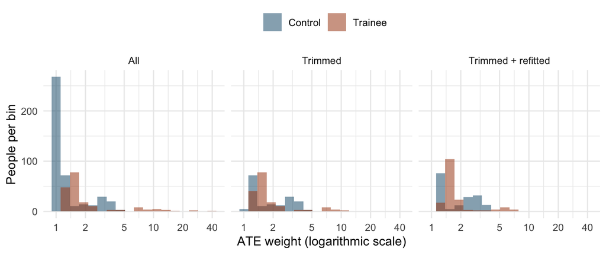

```r
weight_check <- function(d, w) {
  wt <- w[d$treat == 1]
  wc <- w[d$treat == 0]
  c(Trainees = length(wt), Controls = length(wc), Max_trainee = max(wt),
    Max_control = max(wc))
}
round(rbind(Full = weight_check(lalonde, lalonde$w),
            Trimmed = weight_check(job, job$w),
            Refitted = weight_check(job, job$w_refit)), 1)
```

```
##          Trainees Controls Max_trainee Max_control
## Full          185      429        40.1         4.7
## Trimmed       167      166        10.0         4.7
## Refitted      167      166         7.2         4.0
```

Trimming removes 18 trainees and 263 controls and reduces the largest weight from 40.1 to 10.0. Refitting the propensity score model brings it down to 7.2. **Did the smaller weights also improve covariate balance?**

### Step 3. Check covariate balance before and after refitting

For an ATE, use a common scale based on both groups. For each covariate take the square root of the average of its two full-sample group variances. Hold that scale fixed across all five columns. A positive signed SMD means a higher weighted mean among trainees.

```r
z <- lalonde$treat
pooled_sd <- sqrt((apply(x[z == 1, ], 2, var) + apply(x[z == 0, ], 2, var)) / 2)
balance <- cbind(
  All_raw = smd(lalonde, rep(1, nrow(lalonde)), pooled_sd),
  All_IPW = smd(lalonde, lalonde$w, pooled_sd),
  Trim_raw = smd(job, rep(1, nrow(job)), pooled_sd),
  Trim_IPW = smd(job, job$w, pooled_sd),
  Refit_IPW = smd(job, job$w_refit, pooled_sd)
)
round(balance, 2)
```

```
##            All_raw All_IPW Trim_raw Trim_IPW Refit_IPW
## raceblack     1.67    0.13     0.94    -0.20     -0.01
## racehispan   -0.28    0.02    -0.55     0.06      0.02
## racewhite    -1.41   -0.14    -0.50     0.15      0.00
## age          -0.24   -0.17     0.06     0.11      0.03
## educ          0.04    0.13    -0.09     0.00      0.00
## married      -0.72   -0.21     0.01     0.11      0.02
## nodegree      0.24   -0.12     0.12    -0.01     -0.01
## re74         -0.60   -0.27    -0.03     0.15      0.01
## re75         -0.29   -0.16    -0.04     0.12      0.04
```

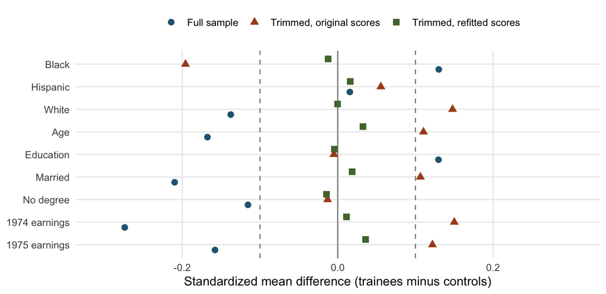

For 1974 earnings, full-sample IPW moves the SMD from −0.60 to −0.27. Within the trimmed sample, the old weights move it from −0.03 unweighted to +0.15 weighted. The Black indicator also changes sign. After refitting, all nine absolute SMDs are below 0.05, so we use the refitted weights for the earnings comparison.

### Step 4. Calculate the weighted earnings difference

Use the refitted weights from Step 3 for the 333 retained people. Subtract the weighted mean of 1978 earnings among controls from the weighted mean among trainees.

```r
weighted_difference <- function(d, w) {
  t <- d$treat == 1
  weighted.mean(d$re78[t], w[t]) - weighted.mean(d$re78[!t], w[!t])
}
ate <- weighted_difference(job, job$w_refit)
round(ate)
```

```
## [1] 969
```

### Step 5. Compare two standard errors

The treatment coefficient in a weighted regression gives the same estimate. Use that regression to get the HC2 standard error, which treats the fitted weights as fixed. For the bootstrap, resample the 333 retained people and refit the propensity model in each draw. Both intervals condition on the trimming decision.

```r
wls <- lm(re78 ~ treat, data = job, weights = w_refit)
se_fixed <- sqrt(sandwich::vcovHC(wls, type = "HC2")["treat", "treat"])
set.seed(24630)
boot_ate <- replicate(2000, {
  b <- job[sample.int(nrow(job), replace = TRUE), ]
  boot_score <- fitted(glm(ps_formula, data = b, family = binomial()))
  weighted_difference(b, ate_weights(b$treat, boot_score))
})
ipw_ci <- interval(ate, sd(boot_ate))
round(rbind(Fixed_weight_HC2 = interval(ate, se_fixed), Refit_bootstrap = ipw_ci))
```

```
##                  Estimate  SE Lower Upper
## Fixed_weight_HC2      969 800  -599  2537
## Refit_bootstrap       969 829  -655  2594
```

The estimated gain in 1978 earnings is $969 for the 167 trainees and 166 controls retained by the weighting rule. The bootstrap 95% interval runs from −$655 to $2,594. The interval includes zero.

## 5. Compare the estimated effects on 1978 earnings

The matching rows use the estimates before regression adjustment and their corresponding intervals from Section 3. The IPW interval uses the bootstrap from Section 4, which refits the propensity score model in each draw.

| Method | Target population | Estimate ($) | 95% CI ($) |
| --- | --- | --- | --- |
| Stratification (Example 6) | ATE, 333 eligible people | 941 | (-797, 2,680) |
| IPW | ATE, 333 eligible people | 969 | (-655, 2,594) |
| One-to-one matching within race | ATT, 106 matched trainees | 920 | (-953, 2,794) |
| Two controls per trainee, with replacement | ATT, 167 matched trainees | 1,397 | (-350, 3,144) |

Stratification and IPW answer the same question for the same 333 people. Averaging the four within-block differences gives an estimate just $28 below the IPW estimate. The two matching estimates answer different questions. Matching within race estimates the effect for the 106 trainees who found a partner. Allowing controls to be reused gives a larger estimate, but it also includes 61 more trainees and changes which controls supply their comparisons.

All four estimates suggest higher earnings after training, but every 95% interval includes zero. The data are compatible with both an earnings loss and a gain under each design.